# Untitled

Goal: To form a model with the best predictors of DEATH_EVENT and to test the model on a holdout set of the original data.

Data Description: The age variables explains the age of the patient. The variable anaemia is a boolean variable that shows whether there was a decrease of red blood cells or hemoglobin. The variable creatinine_phosphokinase shows the level of CPK enzyme in the blood (mcg/L). Diabetes is a boolean variable that shows whether the patient has diabetes or not. The variable ejection_fraction shows the percentage of blood leaving the heart at each contraction (percentage). The variable high_blood_pressure is a boolean variable indicating whether or not a patient has high blood pressure. The variable platelets indicates the number of platelets in the blood (kiloplatelets/mL). The variable serum_creatinine indicates the level of serum creatinine in the blood (mEq/L). THe variable sex is a binary variable indicating woman or man. The variable smoking is a boolean variable indicating whether the patient smokes or not. The variable time indicates the follow-up period in days. The variable DEATH_EVENT is a boolean variable indicating whether the patient deceased during the follow-up period.

```r
head(heart_f)
```

```
## # A tibble: 6 x 13
##     age anaemia creatinine_phos… diabetes ejection_fracti… high_blood_pres…
##   <dbl>   <dbl>            <dbl>    <dbl>            <dbl>            <dbl>
## 1    75       0              582        0               20                1
## 2    55       0             7861        0               38                0
## 3    65       0              146        0               20                0
## 4    50       1              111        0               20                0
## 5    65       1              160        1               20                0
## 6    90       1               47        0               40                1
## # … with 7 more variables: platelets <dbl>, serum_creatinine <dbl>,
## #   serum_sodium <dbl>, sex <dbl>, smoking <dbl>, time <dbl>, DEATH_EVENT <dbl>
```

```r
summary(heart_f)
```

```
##       age           anaemia       creatinine_phosphokinase    diabetes
##  Min.   :40.00   Min.   :0.0000   Min.   :  23.0           Min.   :0.0000
##  1st Qu.:51.00   1st Qu.:0.0000   1st Qu.: 116.5           1st Qu.:0.0000
##  Median :60.00   Median :0.0000   Median : 250.0           Median :0.0000
##  Mean   :60.83   Mean   :0.4314   Mean   : 581.8           Mean   :0.4181
##  3rd Qu.:70.00   3rd Qu.:1.0000   3rd Qu.: 582.0           3rd Qu.:1.0000
##  Max.   :95.00   Max.   :1.0000   Max.   :7861.0           Max.   :1.0000
##  ejection_fraction high_blood_pressure   platelets      serum_creatinine
##  Min.   :14.00     Min.   :0.0000      Min.   : 25100   Min.   :0.500
##  1st Qu.:30.00     1st Qu.:0.0000      1st Qu.:212500   1st Qu.:0.900
##  Median :38.00     Median :0.0000      Median :262000   Median :1.100
##  Mean   :38.08     Mean   :0.3512      Mean   :263358   Mean   :1.394
##  3rd Qu.:45.00     3rd Qu.:1.0000      3rd Qu.:303500   3rd Qu.:1.400
##  Max.   :80.00     Max.   :1.0000      Max.   :850000   Max.   :9.400
##   serum_sodium        sex            smoking            time
##  Min.   :113.0   Min.   :0.0000   Min.   :0.0000   Min.   :  4.0
##  1st Qu.:134.0   1st Qu.:0.0000   1st Qu.:0.0000   1st Qu.: 73.0
##  Median :137.0   Median :1.0000   Median :0.0000   Median :115.0
##  Mean   :136.6   Mean   :0.6488   Mean   :0.3211   Mean   :130.3
##  3rd Qu.:140.0   3rd Qu.:1.0000   3rd Qu.:1.0000   3rd Qu.:203.0
##  Max.   :148.0   Max.   :1.0000   Max.   :1.0000   Max.   :285.0
##   DEATH_EVENT
##  Min.   :0.0000
##  1st Qu.:0.0000
##  Median :0.0000
##  Mean   :0.3211
##  3rd Qu.:1.0000
##  Max.   :1.0000
```

```r
table(heart_f$DEATH_EVENT)
```

```
##
##   0   1
## 203  96
```

## Data Visualizations

```r
set.seed(12142020)
rows <- sample(nrow(heart_f))
heart_f_shuffled = heart_f[rows,]

heart_f_Train=heart_f_shuffled[1:239,]       #select the training sample
heart_f_Test=heart_f_shuffled[239:299,]   #create the holdout sample
```

After taking a look at the data set contents, I split the dataset into training data and testing data (80% and 20% respectively). I randomized the data beforehand to ensure that that there is no bias due to the order of the data set. I also set the seed to the current date to ensure that I can reproduce the same random results.

## Finding best model to predict survival

```r
#Starting with an empty model with no predictors
none = glm(DEATH_EVENT~1, data=heart_f_Train, family="binomial")
#Establish a full model
full_heart_f = glm(DEATH_EVENT~., data=heart_f_Train, family="binomial")
#Stepwise
final_model_both = stepAIC(none, scope=list(upper=full_heart_f), direction="both", trace=TRUE)
```

```
## Start:  AIC=302.42
## DEATH_EVENT ~ 1
##
##                            Df Deviance    AIC
## + time                      1   222.23 226.23
## + ejection_fraction         1   276.82 280.82
## + serum_creatinine          1   277.70 281.70
## + age                       1   282.06 286.06
## + serum_sodium              1   294.11 298.11
## + anaemia                   1   298.39 302.39
## <none>                          300.42 302.42
## + high_blood_pressure       1   298.90 302.90
## + creatinine_phosphokinase  1   298.94 302.94
## + platelets                 1   300.19 304.19
## + smoking                   1   300.30 304.30
## + sex                       1   300.38 304.38
## + diabetes                  1   300.39 304.39
##
## Step:  AIC=226.23
## DEATH_EVENT ~ time
##
##                            Df Deviance    AIC
## + serum_creatinine          1   204.69 210.69
## + ejection_fraction         1   205.91 211.91
## + age                       1   212.26 218.26
## + serum_sodium              1   217.31 223.31
## <none>                          222.23 226.23
## + creatinine_phosphokinase  1   221.48 227.48
## + anaemia                   1   221.78 227.78
## + platelets                 1   221.81 227.81
## + sex                       1   222.07 228.07
## + diabetes                  1   222.13 228.13
## + high_blood_pressure       1   222.18 228.18
## + smoking                   1   222.19 228.19
## - time                      1   300.42 302.42
##
## Step:  AIC=210.69
## DEATH_EVENT ~ time + serum_creatinine
##
##                            Df Deviance    AIC
```

[output cut: 34 more lines]

```
##
##                            Df Deviance    AIC
## <none>                          175.69 185.69
## + creatinine_phosphokinase  1   174.51 186.51
## + sex                       1   174.82 186.82
## + diabetes                  1   175.17 187.17
## + serum_sodium              1   175.37 187.37
## + anaemia                   1   175.57 187.57
## + high_blood_pressure       1   175.67 187.67
## + platelets                 1   175.68 187.68
## + smoking                   1   175.69 187.69
## - age                       1   186.78 194.78
## - serum_creatinine          1   192.65 200.65
## - ejection_fraction         1   197.47 205.47
## - time                      1   236.24 244.24
```

```r
summary(final_model_both)
```

```
##
## Call:
## glm(formula = DEATH_EVENT ~ time + serum_creatinine + ejection_fraction +
##     age, family = "binomial", data = heart_f_Train)
##
## Deviance Residuals:
##     Min       1Q   Median       3Q      Max
## -2.1769  -0.5943  -0.2237   0.4129   2.9378
##
## Coefficients:
##                    Estimate Std. Error z value Pr(>|z|)
## (Intercept)       -0.117665   1.174382  -0.100 0.920191
## time              -0.021114   0.003393  -6.222 4.91e-10 ***
## serum_creatinine   0.776289   0.200125   3.879 0.000105 ***
## ejection_fraction -0.075657   0.018005  -4.202 2.65e-05 ***
## age                0.055289   0.017482   3.163 0.001563 **
## ---
## Signif. codes:  0 '***' 0.001 '**' 0.01 '*' 0.05 '.' 0.1 ' ' 1
##
## (Dispersion parameter for binomial family taken to be 1)
##
##     Null deviance: 300.42  on 238  degrees of freedom
## Residual deviance: 175.69  on 234  degrees of freedom
## AIC: 185.69
##
## Number of Fisher Scoring iterations: 6
```

```r
exp(summary(final_model_both)$coef[1])
```

```
## [1] 0.888994
```

```r
exp(summary(final_model_both)$coef[1]+ summary(final_model_both)$coef[3])
```

```
## [1] 1.932133
```

To find the best model, I used stepwise regression. After several steps, I found that the best model contains time, serum_creatinine, ejection_fraction, and age.

##Individual Plots

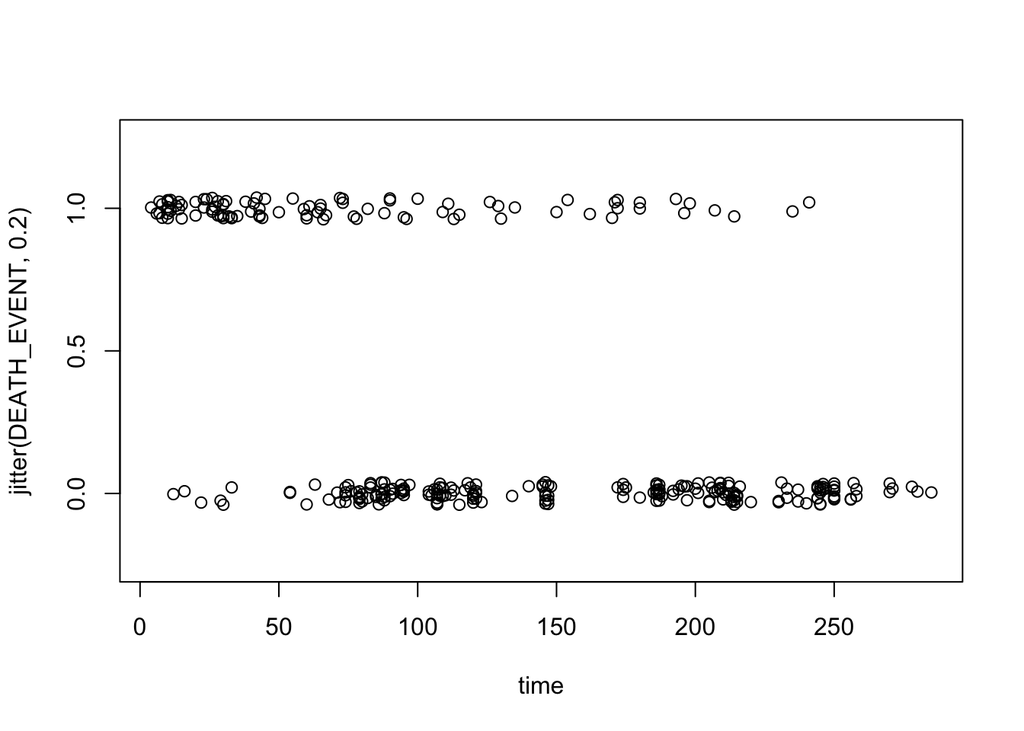

```r
plot(jitter(DEATH_EVENT,.2)~time, ylim=c(-.25,1.25), data=heart_f)
```

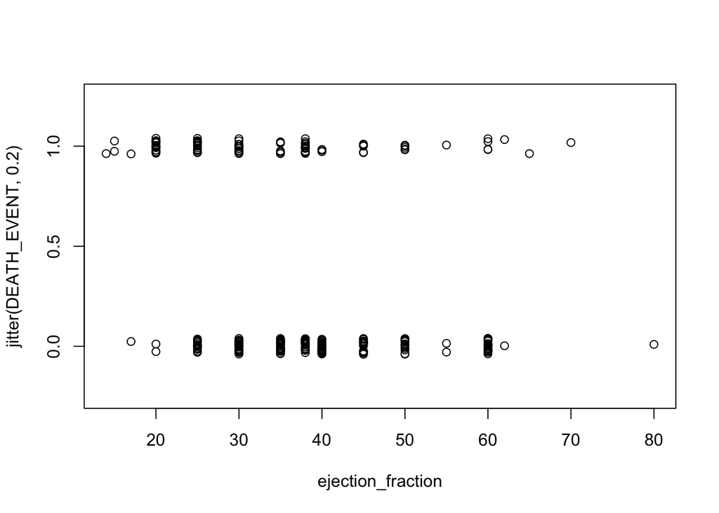

```r
plot(jitter(DEATH_EVENT,.2)~ejection_fraction, ylim=c(-.25,1.25), data=heart_f)
```

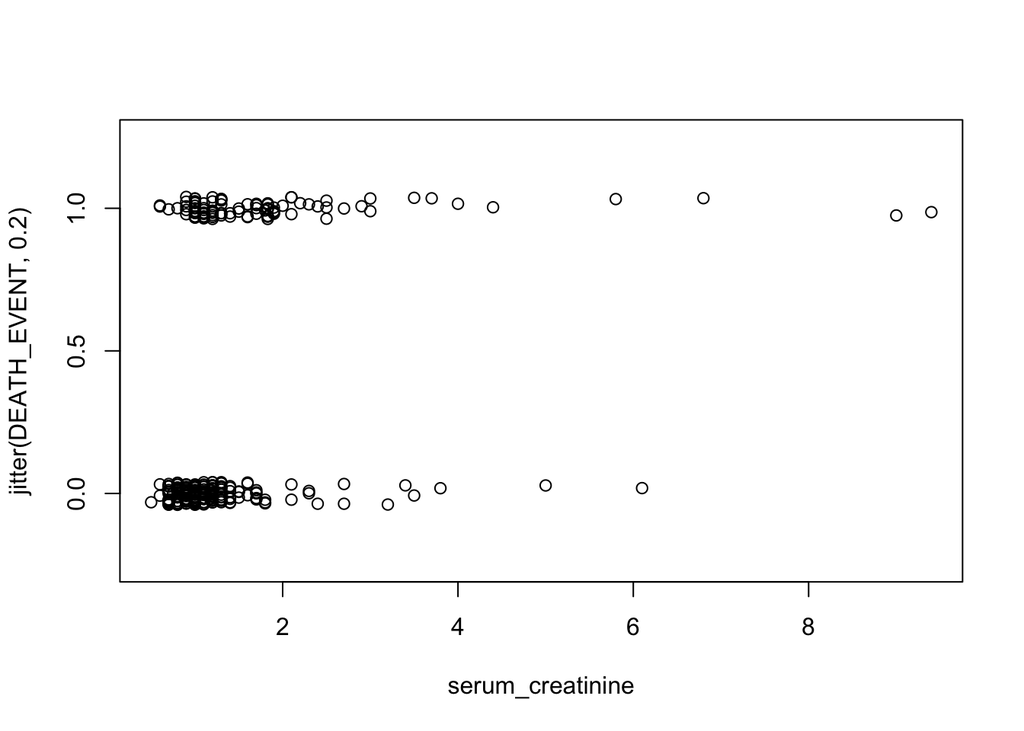

```r
plot(jitter(DEATH_EVENT,.2)~serum_creatinine, ylim=c(-.25,1.25), data=heart_f)
```

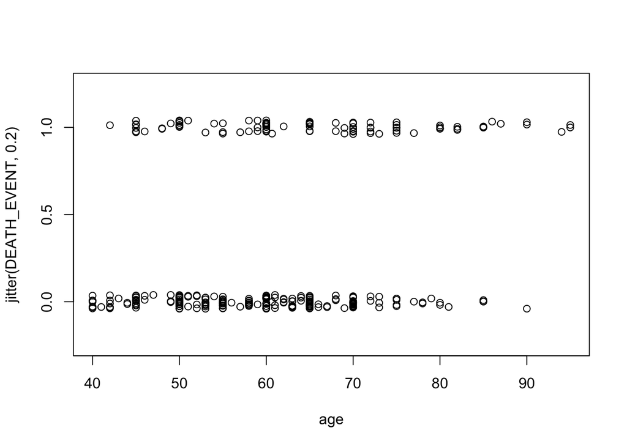

```r
plot(jitter(DEATH_EVENT,.2)~age, ylim=c(-.25,1.25), data=heart_f)
```

```r
exp(confint.default(final_model_both))
```

```
##                        2.5 %    97.5 %
## (Intercept)       0.08897393 8.8824930
## time              0.97261716 0.9856413
## serum_creatinine  1.46822060 3.2172506
## ejection_fraction 0.89498725 0.9604360
## age               1.02124875 1.0936849
```

I took the best predictors found using stepwise regression and individually plotted them against DEATH_EVENT on the y-axis. By doing so, I was hoping to get an idea what kind of relationship each predictor has on the outcome. Some graphs were unclear so I also plotted the confidence interval to get a more accurate idea of what predictors where decreasing the chance of survival. I found the following:

For every unit you add to time, the odds of a patient passing away (DEATH_EVENT=1) are somewhere between 97.3% to 98.6% of what they were when time is one unit smaller with 95% confidence.

For every unit you add to serum_creatinine, the odds of a patient passing away (DEATH_EVENT=1), is somewhere between 146.8% to 321.7% of what they were when serum_creatinine is one unit smaller with 95% confidence.

For every unit you add to ejection_fraction, the odds of a patient passing away (DEATH_EVENT=1) is somewhere between 89.5% to 96.0% of what they were when ejection_fraction is one unit smaller with 95% confidence.

For every unit you add to the age, the odds of a patient passing away (DEATH_EVENT=1) is somewhere between 102.1% to 109.4% of what they were when age is one unit smaller with 95% confidence.

In short, longer follow-up periods (time) and a higher percentage of blood leaving the heart at each contraction (ejection_fraction) increase the chances of survival. On the other hand, higher ages (age) and a higher level of serum creatinine (serum_creatinine) decrease the chances of survival.

## Checking correlation among predictors

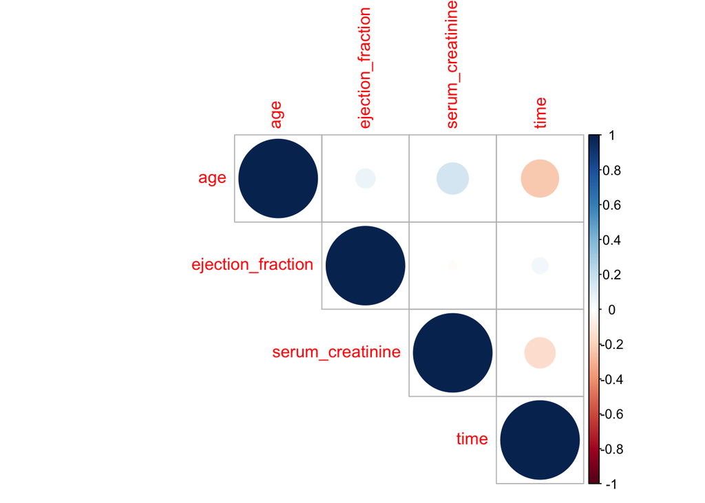

```r
heart_cor_matrix= cor(heart_f[,c(1,5,8,12)])
corrplot(heart_cor_matrix, type="upper")
```

```r
vif(final_model_both)
```

```
##              time  serum_creatinine ejection_fraction               age
##          1.080549          1.091686          1.109236          1.071307
```

The VIFs are low enough to say that there is not much correlation among predictors. I included a visual to show the lack of correlation.

## Looking at Residuals

```r
heart_f_Test$Predicted=predict(final_model_both, heart_f_Test, type="response")
heart_f_Test$BooleanPred = ifelse(heart_f_Test$Predicted < .5, 0, 1)

CorrectPredictionPercentage=sum(heart_f_Test$DEATH_EVENT == heart_f_Test$BooleanPred)/61
CorrectPredictionPercentage
```

```
## [1] 0.8196721
```

After looking at the relationship between the predictor and the response variables in the testing, I used the model to predict DEATH_EVENT for the test data set. I then created a column in the test data set to show the predicted values for each row. Since the predicted values were not binary, I created a new column using an ifelse statement. If the predicted values were less than .5, the new column indicated a 0. If the predicted values were greater than or equal to .5, the new column indicated a 1. I think compared the predicted values with the actual values of DEATH_EVENT. The model predicted the actual outcome 82% of the time.

## Predicting the survival of a hypothetical individual

```r
newx=data.frame(time=mean(heart_f$time), serum_creatinine=mean(heart_f$serum_creatinine), ejection_fraction=mean(heart_f$ejection_fraction),
    age=mean(heart_f$age))
predict.glm(final_model_both, newx, type="response")
```

```
##         1
## 0.2135382
```

Here, I created a hypothetical situation. For all of the significant predictors, I took the mean values from the original dataset and created a new data frame. I then used the predict function to predict the survival of the hypothetical individual. This predicted value for the hypothetical individual is .214. This rounds down to a 0 (which translates to survival). This output makes sense because a majority of the people in the data set survived (203 compared to 96).